# Objective

To train colleagues the steps involed in a simple Machine Learning project (Regression)

# Load data

```python
import pandas as pd
```

```python
# Read csv file
housing = pd.read_csv('datasets/housing/housing.csv')
# Quick view of the top 5 rows of the dataset
housing.head()
```

|  | longitude | latitude | housing_median_age | total_rooms | total_bedrooms | population | households | median_income | median_house_value | ocean_proximity |
| --- | --- | --- | --- | --- | --- | --- | --- | --- | --- | --- |
| 0 | -122.23 | 37.88 | 41.0 | 880.0 | 129.0 | 322.0 | 126.0 | 8.3252 | 452600.0 | NEAR BAY |
| 1 | -122.22 | 37.86 | 21.0 | 7099.0 | 1106.0 | 2401.0 | 1138.0 | 8.3014 | 358500.0 | NEAR BAY |
| 2 | -122.24 | 37.85 | 52.0 | 1467.0 | 190.0 | 496.0 | 177.0 | 7.2574 | 352100.0 | NEAR BAY |
| 3 | -122.25 | 37.85 | 52.0 | 1274.0 | 235.0 | 558.0 | 219.0 | 5.6431 | 341300.0 | NEAR BAY |
| 4 | -122.25 | 37.85 | 52.0 | 1627.0 | 280.0 | 565.0 | 259.0 | 3.8462 | 342200.0 | NEAR BAY |

```python
# Get description of the data
housing.info()
```

```
<class 'pandas.core.frame.DataFrame'>
RangeIndex: 20640 entries, 0 to 20639
Data columns (total 10 columns):
longitude             20640 non-null float64
latitude              20640 non-null float64
housing_median_age    20640 non-null float64
total_rooms           20640 non-null float64
total_bedrooms        20433 non-null float64
population            20640 non-null float64
households            20640 non-null float64
median_income         20640 non-null float64
median_house_value    20640 non-null float64
ocean_proximity       20640 non-null object
dtypes: float64(9), object(1)
memory usage: 1.6+ MB
```

- 20640 instances in the dataset
  - Fairly small by ML standards
- total_bedrooms is missing some data
- all attributes are of float datatype except ocean_proximity
  - since it is of object datatype, it can hold any type of python object
  - but we loaded it from a csv file, so chances are it is text

**Summary of categorical attributes**

```python
# Checking if ocean_proximity is a categorical attribute
housing['ocean_proximity'].value_counts()
```

```
<1H OCEAN     9136
INLAND        6551
NEAR OCEAN    2658
NEAR BAY      2290
ISLAND           5
Name: ocean_proximity, dtype: int64
```

**Summary of numerical attributes**

```python
housing.describe()
```

|  | longitude | latitude | housing_median_age | total_rooms | total_bedrooms | population | households | median_income | median_house_value |
| --- | --- | --- | --- | --- | --- | --- | --- | --- | --- |
| count | 20640.000000 | 20640.000000 | 20640.000000 | 20640.000000 | 20433.000000 | 20640.000000 | 20640.000000 | 20640.000000 | 20640.000000 |
| mean | -119.569704 | 35.631861 | 28.639486 | 2635.763081 | 537.870553 | 1425.476744 | 499.539680 | 3.870671 | 206855.816909 |
| std | 2.003532 | 2.135952 | 12.585558 | 2181.615252 | 421.385070 | 1132.462122 | 382.329753 | 1.899822 | 115395.615874 |
| min | -124.350000 | 32.540000 | 1.000000 | 2.000000 | 1.000000 | 3.000000 | 1.000000 | 0.499900 | 14999.000000 |
| 25% | -121.800000 | 33.930000 | 18.000000 | 1447.750000 | 296.000000 | 787.000000 | 280.000000 | 2.563400 | 119600.000000 |
| 50% | -118.490000 | 34.260000 | 29.000000 | 2127.000000 | 435.000000 | 1166.000000 | 409.000000 | 3.534800 | 179700.000000 |
| 75% | -118.010000 | 37.710000 | 37.000000 | 3148.000000 | 647.000000 | 1725.000000 | 605.000000 | 4.743250 | 264725.000000 |
| max | -114.310000 | 41.950000 | 52.000000 | 39320.000000 | 6445.000000 | 35682.000000 | 6082.000000 | 15.000100 | 500001.000000 |

- Null values are ignored by describe()
- *std* - Standard deviation, how dispersed are the values.
- *25%*, *50%*, *75%* - percentiles
  - These indivate the value below which the given percentage of observations in a group of values fall

```
- 25% (First Quartile)
    - 25% of the districts have a median age of lower than 18


- 50% (Median)
    - 50% of the districts have a median age of lower than 29


- 75% (3rd Quartile)
    - 75% of the districts have a median age of lower than 37
```

Another way of getting a feel of each of the numerical data types is by using a histogram.

A histogram is used to check the distribution. It shows the number of instances(rows) on the vertical axis that have a given value range on the horizontal axis.

You can create a histogram of each individual attribute - one at a time or use the hist() methods on the whole dataset.

```python
import matplotlib.pyplot as plt
# This tell Jupyter to set up Matplotlib so it uses Jupyter's own backend
# to render the plots/graphs within the notebook itself
%matplotlib inline
```

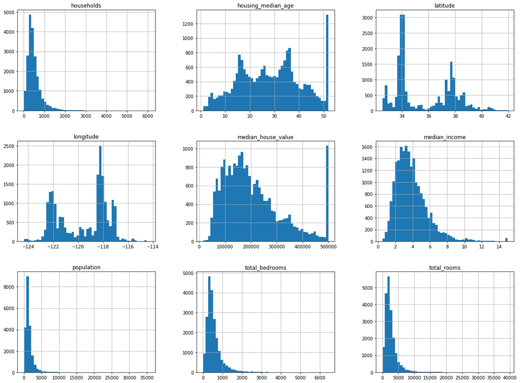

```python
housing.hist(bins = 50, figsize = (20, 15))
# Calling show is actually optional in Jupyter Notebooks
plt.show()
```

**A note on Standard Deviation**

Standard deviation(denoted using Greek letter sigma) is the square root of the variance.

The variance is the average of the squared deviations from the mean.

If a feature has a normal distribution(bell shaped curve) also called a gaussian distribution, the **68-95-99.7** rule applies.

**68-95-99.7** - Close to 68% of the values fall within one standard deviation, 95% of the values fall within two standard deviations, and 99.7% fall within three standard deviations.

**Insights from the Histograms**

- The median income is not in USD. It has been scaled. Check the x axis. It is also capped at approx 15 (Higher median income) and 0.5 (Lower median income). The numbers on the x axis represent the income in approx USD 10,000. So 3 can be thought of as USD 30,000
- Having preprocessed attributes to you is quite common. But you must know and try to understand how it was computed.
- The median age and median house value were also capped.
  - The median house value is our label (what we want to predict). Since it is capped, the problem is that the algorithms might learn that prices do not go beyond UDS 5,00,000. There are a lot of instances representing it.
  - This is where you go back to the business people and discuss it. If they need the system to precisely predict the median values beyond USD 5,00,000 then:
    - Collect data(labels) for districts that were capped.
    - Remove these districts from the training set and the test set.The system must not be evaluated poorly if it predicts the values beyond UDS 5,00,000
- The attributes are at different scales. We need to scale the features.
- Few of the histograms are tail heavy - extend more towards the right of the median than to the left. We need to transform these attributes to make them more normalized

# Create a test set

We will create a test set. Put is aside. Never look at it till the end.

Data snooping bias - Our brains are amazing at detecting patterns. We might detect some pattern in the test set.

```python
import numpy as np
```

```python
# from sklearn.model_selection import train_test_split
```

```python
# train_set, test_set = train_test_split(housing, test_size = 0.2, random_state = 42)
```

- Setting the random state tells it to always generate the same random number
- Why 42?
  - It is the answer to the ultimate question of life, the universe, and everything.

```python
housing['income_cat'] = pd.cut(housing["median_income"], bins = [0., 1.5, 3.0, 4.5, 6., np.inf], labels = [1,2,3,4,5])
```

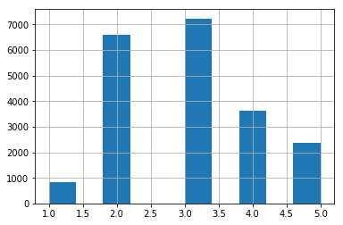

```python
housing['income_cat'].hist()
```

Histogram of income categories

**Stratified sampling based on the income category**

```python
from sklearn.model_selection import StratifiedShuffleSplit
```

```python
split = StratifiedShuffleSplit(n_splits = 1, test_size = 0.2, random_state = 42)
```

```python
split
```

```
StratifiedShuffleSplit(n_splits=1, random_state=42, test_size=0.2,
            train_size=None)
```

```python
for train_index, test_index in split.split(housing, housing['income_cat']):
    strat_train_set = housing.loc[train_index]
    strat_test_set = housing.loc[test_index]
```

```python
strat_test_set['income_cat'].value_counts()/len(strat_test_set)
```

```
3    0.350533
2    0.318798
4    0.176357
5    0.114583
1    0.039729
Name: income_cat, dtype: float64
```

```python
housing['income_cat'].value_counts()/len(housing)
```

```
3    0.350581
2    0.318847
4    0.176308
5    0.114438
1    0.039826
Name: income_cat, dtype: float64
```

- These are almost the same, so we are representing all the median income values equally

```python
# Removing income_cat attribute to convert the data back to its original state
for set_ in (strat_train_set, strat_test_set):
    set_.drop('income_cat', axis = 1, inplace = True)
```

# EDA

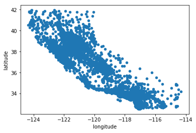

```python
# Since we have geographical information
# We can create scatterplots to visualize the data
housing.plot(kind = 'scatter', x='longitude', y = 'latitude')
```

- Looks like California
- But this is not providing us with a lot of insights.
- To visualize the high density areas, we can set the *alpha* option to 0.1

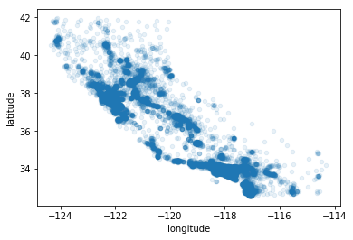

```python
housing.plot(kind = 'scatter', x='longitude', y = 'latitude', alpha=0.1)
```

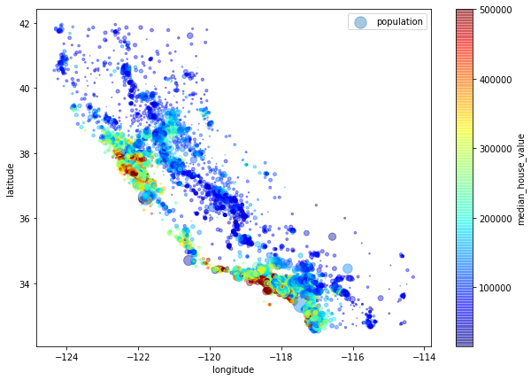

```python
# Making it even better
housing.plot(kind = 'scatter', x='longitude', y = 'latitude', alpha=0.4,
            s=housing['population']/100, label = 'population', figsize=(10, 7),
            c='median_house_value', cmap=plt.get_cmap('jet'), colorbar=True)
plt.legend()
```

- House prices are heavily dependent on their proximity to the ocean.
- This is not exactly the case in the Northern areas.
- We can use clustering to figure out the main cluesters

**Checking correlation**

```python
correlation_matrix = housing.corr()
correlation_matrix
```

|  | longitude | latitude | housing_median_age | total_rooms | total_bedrooms | population | households | median_income | median_house_value |
| --- | --- | --- | --- | --- | --- | --- | --- | --- | --- |
| longitude | 1.000000 | -0.924664 | -0.108197 | 0.044568 | 0.069608 | 0.099773 | 0.055310 | -0.015176 | -0.045967 |
| latitude | -0.924664 | 1.000000 | 0.011173 | -0.036100 | -0.066983 | -0.108785 | -0.071035 | -0.079809 | -0.144160 |
| housing_median_age | -0.108197 | 0.011173 | 1.000000 | -0.361262 | -0.320451 | -0.296244 | -0.302916 | -0.119034 | 0.105623 |
| total_rooms | 0.044568 | -0.036100 | -0.361262 | 1.000000 | 0.930380 | 0.857126 | 0.918484 | 0.198050 | 0.134153 |
| total_bedrooms | 0.069608 | -0.066983 | -0.320451 | 0.930380 | 1.000000 | 0.877747 | 0.979728 | -0.007723 | 0.049686 |
| population | 0.099773 | -0.108785 | -0.296244 | 0.857126 | 0.877747 | 1.000000 | 0.907222 | 0.004834 | -0.024650 |
| households | 0.055310 | -0.071035 | -0.302916 | 0.918484 | 0.979728 | 0.907222 | 1.000000 | 0.013033 | 0.065843 |
| median_income | -0.015176 | -0.079809 | -0.119034 | 0.198050 | -0.007723 | 0.004834 | 0.013033 | 1.000000 | 0.688075 |
| median_house_value | -0.045967 | -0.144160 | 0.105623 | 0.134153 | 0.049686 | -0.024650 | 0.065843 | 0.688075 | 1.000000 |

```python
# To check how much each attribute correlates to a single attribute
correlation_matrix['median_house_value'].sort_values(ascending=False)
```

```
median_house_value    1.000000
median_income         0.688075
total_rooms           0.134153
housing_median_age    0.105623
households            0.065843
total_bedrooms        0.049686
population           -0.024650
longitude            -0.045967
latitude             -0.144160
Name: median_house_value, dtype: float64
```

[output not shown]

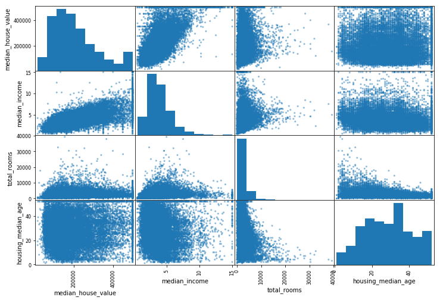

```python
# Visualising correlations
from pandas.plotting import scatter_matrix

attributes = ['median_house_value', 'median_income', 'total_rooms', 'housing_median_age']
scatter_matrix(housing[attributes], figsize = (12, 8))
```

- median income is the most promising attribute to predict the median house value
- Lets plot it seperately

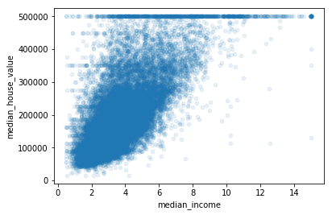

```python
housing.plot(kind='scatter', x='median_income', y='median_house_value', alpha=0.1)
```

- Good correlation
- Upwards trend
- Points not too dispersed
- Notice the price cap, straight horizontal line at the top of the graph.
- Another one at about 4,50,000
- Another one at about 3,50,000
- a few more

## Feature Engineering

```python
housing['rooms_per_household'] = housing['total_rooms']/housing['households']
```

```python
housing['bedrooms_per_room'] = housing['total_bedrooms']/housing['total_rooms']
```

```python
housing['population_per_household'] = housing['population']/housing['households']
```

```python
correlation_matrix = housing.corr()
correlation_matrix
```

|  | longitude | latitude | housing_median_age | total_rooms | total_bedrooms | population | households | median_income | median_house_value | rooms_per_household | bedrooms_per_room | population_per_household |
| --- | --- | --- | --- | --- | --- | --- | --- | --- | --- | --- | --- | --- |
| longitude | 1.000000 | -0.924664 | -0.108197 | 0.044568 | 0.069608 | 0.099773 | 0.055310 | -0.015176 | -0.045967 | -0.027540 | 0.092657 | 0.002476 |
| latitude | -0.924664 | 1.000000 | 0.011173 | -0.036100 | -0.066983 | -0.108785 | -0.071035 | -0.079809 | -0.144160 | 0.106389 | -0.113815 | 0.002366 |
| housing_median_age | -0.108197 | 0.011173 | 1.000000 | -0.361262 | -0.320451 | -0.296244 | -0.302916 | -0.119034 | 0.105623 | -0.153277 | 0.136089 | 0.013191 |
| total_rooms | 0.044568 | -0.036100 | -0.361262 | 1.000000 | 0.930380 | 0.857126 | 0.918484 | 0.198050 | 0.134153 | 0.133798 | -0.187900 | -0.024581 |
| total_bedrooms | 0.069608 | -0.066983 | -0.320451 | 0.930380 | 1.000000 | 0.877747 | 0.979728 | -0.007723 | 0.049686 | 0.001538 | 0.084238 | -0.028355 |
| population | 0.099773 | -0.108785 | -0.296244 | 0.857126 | 0.877747 | 1.000000 | 0.907222 | 0.004834 | -0.024650 | -0.072213 | 0.035319 | 0.069863 |
| households | 0.055310 | -0.071035 | -0.302916 | 0.918484 | 0.979728 | 0.907222 | 1.000000 | 0.013033 | 0.065843 | -0.080598 | 0.065087 | -0.027309 |
| median_income | -0.015176 | -0.079809 | -0.119034 | 0.198050 | -0.007723 | 0.004834 | 0.013033 | 1.000000 | 0.688075 | 0.326895 | -0.615661 | 0.018766 |
| median_house_value | -0.045967 | -0.144160 | 0.105623 | 0.134153 | 0.049686 | -0.024650 | 0.065843 | 0.688075 | 1.000000 | 0.151948 | -0.255880 | -0.023737 |
| rooms_per_household | -0.027540 | 0.106389 | -0.153277 | 0.133798 | 0.001538 | -0.072213 | -0.080598 | 0.326895 | 0.151948 | 1.000000 | -0.416952 | -0.004852 |
| bedrooms_per_room | 0.092657 | -0.113815 | 0.136089 | -0.187900 | 0.084238 | 0.035319 | 0.065087 | -0.615661 | -0.255880 | -0.416952 | 1.000000 | 0.002938 |
| population_per_household | 0.002476 | 0.002366 | 0.013191 | -0.024581 | -0.028355 | 0.069863 | -0.027309 | 0.018766 | -0.023737 | -0.004852 | 0.002938 | 1.000000 |

```python
correlation_matrix['median_house_value'].sort_values(ascending=False)
```

```
median_house_value          1.000000
median_income               0.688075
rooms_per_household         0.151948
total_rooms                 0.134153
housing_median_age          0.105623
households                  0.065843
total_bedrooms              0.049686
population_per_household   -0.023737
population                 -0.024650
longitude                  -0.045967
latitude                   -0.144160
bedrooms_per_room          -0.255880
Name: median_house_value, dtype: float64
```

- From the new attributes that we created, bedrooms_per_room is the most correlated with the median_house_value
- the lower the bedroom/room ration, the more expensive is the house - usually.
- rooms_per_household provides more information than total_rooms in a district. The larger the house, the more expensive it tends to be.
- We will not explore any further for now.
- Exploration too is an iterative process.
- We have a fairly good idea about our data as of now.

# Prepare Data

- For a habit of writing functions for these

```python
# Get the clean training set
housing = strat_train_set.drop('median_house_value', axis = 1)
housing_labels = strat_train_set['median_house_value'].copy()
```

## Cleaning data

```python
from sklearn.impute import SimpleImputer
imputer = SimpleImputer(strategy="median")
```

```python
imputer
```

```
SimpleImputer(add_indicator=False, copy=True, fill_value=None,
              missing_values=nan, strategy='median', verbose=0)
```

```python
# Dropping categorical attributes
housing_num = housing.drop("ocean_proximity", axis=1)
```

```python
imputer.fit(housing_num)
```

```
SimpleImputer(add_indicator=False, copy=True, fill_value=None,
              missing_values=nan, strategy='median', verbose=0)
```

```python
imputer.statistics_
```

```
array([-118.51  ,   34.26  ,   29.    , 2119.5   ,  433.    , 1164.    ,
        408.    ,    3.5409])
```

```python
# This should be the same as above
housing_num.median().values
```

```
array([-118.51  ,   34.26  ,   29.    , 2119.5   ,  433.    , 1164.    ,
        408.    ,    3.5409])
```

```python
# Transfor the training set using the imputer
X = imputer.transform(housing_num)
```

```python
housing_tr = pd.DataFrame(X, columns = housing_num.columns, index = housing.index)
```

```python
housing_tr.isnull().sum()
```

```
longitude             0
latitude              0
housing_median_age    0
total_rooms           0
total_bedrooms        0
population            0
households            0
median_income         0
dtype: int64
```

```python
housing_tr.head()
```

|  | longitude | latitude | housing_median_age | total_rooms | total_bedrooms | population | households | median_income |
| --- | --- | --- | --- | --- | --- | --- | --- | --- |
| 17606 | -121.89 | 37.29 | 38.0 | 1568.0 | 351.0 | 710.0 | 339.0 | 2.7042 |
| 18632 | -121.93 | 37.05 | 14.0 | 679.0 | 108.0 | 306.0 | 113.0 | 6.4214 |
| 14650 | -117.20 | 32.77 | 31.0 | 1952.0 | 471.0 | 936.0 | 462.0 | 2.8621 |
| 3230 | -119.61 | 36.31 | 25.0 | 1847.0 | 371.0 | 1460.0 | 353.0 | 1.8839 |
| 3555 | -118.59 | 34.23 | 17.0 | 6592.0 | 1525.0 | 4459.0 | 1463.0 | 3.0347 |

**Preprocessing categorical features**

```python
housing_cat = housing[['ocean_proximity']]
housing_cat.sample(5)
```

|  | ocean_proximity |
| --- | --- |
| 13190 | INLAND |
| 8066 | NEAR OCEAN |
| 19256 | <1H OCEAN |
| 410 | NEAR BAY |
| 9739 | <1H OCEAN |

```python
# One hot encoding
from sklearn.preprocessing import OneHotEncoder
```

```python
cat_ohe = OneHotEncoder()
```

```python
housing_cat_hot = cat_ohe.fit_transform(housing_cat)
```

```python
housing_cat_hot
```

```
<16512x5 sparse matrix of type '<class 'numpy.float64'>'
	with 16512 stored elements in Compressed Sparse Row format>
```

These matrix is full of zeros except for a single 1 per row - One Hot

```python
housing_cat_hot.toarray()
```

```
array([[1., 0., 0., 0., 0.],
       [1., 0., 0., 0., 0.],
       [0., 0., 0., 0., 1.],
       ...,
       [0., 1., 0., 0., 0.],
       [1., 0., 0., 0., 0.],
       [0., 0., 0., 1., 0.]])
```

```python
cat_ohe.categories_
```

```
[array(['<1H OCEAN', 'INLAND', 'ISLAND', 'NEAR BAY', 'NEAR OCEAN'],
       dtype=object)]
```

# Custom Transformers

```python
from sklearn.base import BaseEstimator, TransformerMixin
```

```python
# column index
rooms_ix, bedrooms_ix, population_ix, households_ix = 3, 4, 5, 6

class CombinedAttributesAdder(BaseEstimator, TransformerMixin):
    def __init__(self, add_bedrooms_per_room = True): # no *args or **kargs
        self.add_bedrooms_per_room = add_bedrooms_per_room
    def fit(self, X, y=None):
        return self  # nothing else to do
    def transform(self, X, y=None):
        rooms_per_household = X[:, rooms_ix] / X[:, households_ix]
        population_per_household = X[:, population_ix] / X[:, households_ix]
        if self.add_bedrooms_per_room:
            bedrooms_per_room = X[:, bedrooms_ix] / X[:, rooms_ix]
            return np.c_[X, rooms_per_household, population_per_household,
                         bedrooms_per_room]
        else:
            return np.c_[X, rooms_per_household, population_per_household]

attr_adder = CombinedAttributesAdder(add_bedrooms_per_room=False)
housing_extra_attribs = attr_adder.transform(housing.values)
```

```python
housing_extra_attribs = pd.DataFrame(
    housing_extra_attribs,
    columns=list(housing.columns)+["rooms_per_household", "population_per_household"],
    index=housing.index)
housing_extra_attribs.head()
```

|  | longitude | latitude | housing_median_age | total_rooms | total_bedrooms | population | households | median_income | ocean_proximity | rooms_per_household | population_per_household |
| --- | --- | --- | --- | --- | --- | --- | --- | --- | --- | --- | --- |
| 17606 | -121.89 | 37.29 | 38 | 1568 | 351 | 710 | 339 | 2.7042 | <1H OCEAN | 4.62537 | 2.0944 |
| 18632 | -121.93 | 37.05 | 14 | 679 | 108 | 306 | 113 | 6.4214 | <1H OCEAN | 6.00885 | 2.70796 |
| 14650 | -117.2 | 32.77 | 31 | 1952 | 471 | 936 | 462 | 2.8621 | NEAR OCEAN | 4.22511 | 2.02597 |
| 3230 | -119.61 | 36.31 | 25 | 1847 | 371 | 1460 | 353 | 1.8839 | INLAND | 5.23229 | 4.13598 |
| 3555 | -118.59 | 34.23 | 17 | 6592 | 1525 | 4459 | 1463 | 3.0347 | <1H OCEAN | 4.50581 | 3.04785 |

## Feature Scaling

Most algorithms do not perform well if the numerical attributes have very different scales.

In our case, total_rooms and median_income are on completely different scales.

Two ways to make the attributes have the same scale

1. Min-Max scaling or Normalization
2. Standardization

**Normalization**

Values are shifted so that they end up ranging from 0 to 1. Subtract the min vale and dive by the max minus the min.

**Standardization**

It first subtracts the mean value. Hence, standardized values always have zero mean.

Then the values are divided by the SD. The resultant distribution has unit variance.

Unlike Normalization, standardization does not bound to a specific range. But standardization is less affected by outliers.

**IMP**

Fit the scalers to training data only. Never on the full dataset (inc the test). Once fitted, use them totransform the traning set and the testing set

```python
from sklearn.pipeline import Pipeline
from sklearn.preprocessing import StandardScaler
```

```python
numeric_pipeline = Pipeline([
    ('imputer', SimpleImputer(strategy='median')),
    ('attrib_adder', CombinedAttributesAdder()),
    ('std_scaler', StandardScaler())
])
```

```python
housing_num_tr = numeric_pipeline.fit_transform(housing_num)
```

# Combining transformers

```python
from sklearn.compose import ColumnTransformer
```

```python
num_attrs = list(housing_num)
cat_attrs = ['ocean_proximity']
```

```python
full_pipeline = ColumnTransformer([
        ("num", numeric_pipeline, num_attrs),
        ("cat", OneHotEncoder(), cat_attrs),
    ])
```

```python
housing_prepared = full_pipeline.fit_transform(housing)
```

```python
housing_prepared.shape
```

```
(16512, 16)
```

# Select and Train model

## Linear Regression

```python
from sklearn.linear_model import LinearRegression
```

```python
linReg = LinearRegression()
```

```python
linReg
```

```
LinearRegression(copy_X=True, fit_intercept=True, n_jobs=None, normalize=False)
```

```python
linReg.fit(housing_prepared, housing_labels)
```

```
LinearRegression(copy_X=True, fit_intercept=True, n_jobs=None, normalize=False)
```

```python
x_test = strat_test_set.drop('median_house_value', axis=1)
y_test = strat_test_set['median_house_value'].copy()
```

```python
x_test_prepared = full_pipeline.transform(x_test)
```

```python
linreg_predictions = linReg.predict(x_test_prepared)
```

```python
linreg_predictions
```

```
array([424327.91587129, 264520.09425443, 228109.45155968, ...,
       290423.67564301, 192142.16080923, 151202.36199678])
```

# Evaluate the model

```python
from sklearn.metrics import mean_squared_error, mean_absolute_error
```

```python
linreg_mse = mean_squared_error(y_test, linreg_predictions)
linreg_mse
```

```
4477213162.344775
```

```python
linreg_rmse = np.sqrt(linreg_mse)
linreg_rmse
```

```
66911.98070857546
```

```python
linreg_mae = mean_absolute_error(y_test, linreg_predictions)
linreg_mae
```

```
49228.615664954195
```

```python
linReg.coef_
```

```
array([-55650.4116403 , -56716.45236929,  13732.83841856,  -1933.1277138 ,
         7330.04062103, -45708.26306673,  45455.47519691,  74714.39134154,
         6605.12802802,   1042.95709453,   9249.75886697, -18016.52432168,
       -55219.15208555, 110357.78363967, -22479.84008184, -14642.2671506 ])
```

```python
linReg.intercept_
```

```
236914.99732815975
```

```python
df_result = pd.DataFrame({'Actual': y_test, 'Predicted': linreg_predictions})

df_result = df_result.sample(30)
```

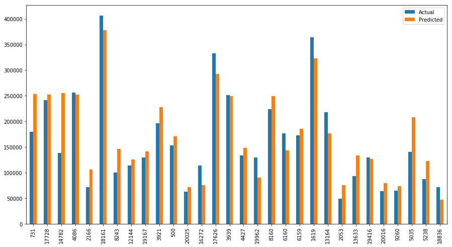

```python
df_result.plot(kind='bar',figsize=(15,8))
plt.show()
```